# Lung Cancer

Liam Murphy

2024-11-14

```r
# View the structure of the dataset
str(lc_data)
```

```
## 'data.frame':    309 obs. of  16 variables:
##  $ GENDER               : chr  "M" "M" "F" "M" ...
##  $ AGE                  : int  69 74 59 63 63 75 52 51 68 53 ...
##  $ SMOKING              : int  1 2 1 2 1 1 2 2 2 2 ...
##  $ YELLOW_FINGERS       : int  2 1 1 2 2 2 1 2 1 2 ...
##  $ ANXIETY              : int  2 1 1 2 1 1 1 2 2 2 ...
##  $ PEER_PRESSURE        : int  1 1 2 1 1 1 1 2 1 2 ...
##  $ CHRONIC.DISEASE      : int  1 2 1 1 1 2 1 1 1 2 ...
##  $ FATIGUE              : int  2 2 2 1 1 2 2 2 2 1 ...
##  $ ALLERGY              : int  1 2 1 1 1 2 1 2 1 2 ...
##  $ WHEEZING             : int  2 1 2 1 2 2 2 1 1 1 ...
##  $ ALCOHOL.CONSUMING    : int  2 1 1 2 1 1 2 1 1 2 ...
##  $ COUGHING             : int  2 1 2 1 2 2 2 1 1 1 ...
##  $ SHORTNESS.OF.BREATH  : int  2 2 2 1 2 2 2 2 1 1 ...
##  $ SWALLOWING.DIFFICULTY: int  2 2 1 2 1 1 1 2 1 2 ...
##  $ CHEST.PAIN           : int  2 2 2 2 1 1 2 1 1 2 ...
##  $ LUNG_CANCER          : chr  "YES" "YES" "NO" "NO" ...
```

```r
# Summary of the dataset
summary(lc_data)
```

```
##     GENDER               AGE           SMOKING      YELLOW_FINGERS
##  Length:309         Min.   :21.00   Min.   :1.000   Min.   :1.00
##  Class :character   1st Qu.:57.00   1st Qu.:1.000   1st Qu.:1.00
##  Mode  :character   Median :62.00   Median :2.000   Median :2.00
##                     Mean   :62.67   Mean   :1.563   Mean   :1.57
##                     3rd Qu.:69.00   3rd Qu.:2.000   3rd Qu.:2.00
##                     Max.   :87.00   Max.   :2.000   Max.   :2.00
##     ANXIETY      PEER_PRESSURE   CHRONIC.DISEASE    FATIGUE
##  Min.   :1.000   Min.   :1.000   Min.   :1.000   Min.   :1.000
##  1st Qu.:1.000   1st Qu.:1.000   1st Qu.:1.000   1st Qu.:1.000
##  Median :1.000   Median :2.000   Median :2.000   Median :2.000
##  Mean   :1.498   Mean   :1.502   Mean   :1.505   Mean   :1.673
##  3rd Qu.:2.000   3rd Qu.:2.000   3rd Qu.:2.000   3rd Qu.:2.000
##  Max.   :2.000   Max.   :2.000   Max.   :2.000   Max.   :2.000
##     ALLERGY         WHEEZING     ALCOHOL.CONSUMING    COUGHING
##  Min.   :1.000   Min.   :1.000   Min.   :1.000     Min.   :1.000
##  1st Qu.:1.000   1st Qu.:1.000   1st Qu.:1.000     1st Qu.:1.000
##  Median :2.000   Median :2.000   Median :2.000     Median :2.000
##  Mean   :1.557   Mean   :1.557   Mean   :1.557     Mean   :1.579
##  3rd Qu.:2.000   3rd Qu.:2.000   3rd Qu.:2.000     3rd Qu.:2.000
##  Max.   :2.000   Max.   :2.000   Max.   :2.000     Max.   :2.000
##  SHORTNESS.OF.BREATH SWALLOWING.DIFFICULTY   CHEST.PAIN    LUNG_CANCER
##  Min.   :1.000       Min.   :1.000         Min.   :1.000   Length:309
##  1st Qu.:1.000       1st Qu.:1.000         1st Qu.:1.000   Class :character
##  Median :2.000       Median :1.000         Median :2.000   Mode  :character
##  Mean   :1.641       Mean   :1.469         Mean   :1.557
##  3rd Qu.:2.000       3rd Qu.:2.000         3rd Qu.:2.000
##  Max.   :2.000       Max.   :2.000         Max.   :2.000
```

```r
# Check for NAs
colSums(is.na(lc_data))
```

```
##                GENDER                   AGE               SMOKING
##                     0                     0                     0
##        YELLOW_FINGERS               ANXIETY         PEER_PRESSURE
##                     0                     0                     0
##       CHRONIC.DISEASE               FATIGUE               ALLERGY
##                     0                     0                     0
##              WHEEZING     ALCOHOL.CONSUMING              COUGHING
##                     0                     0                     0
##   SHORTNESS.OF.BREATH SWALLOWING.DIFFICULTY            CHEST.PAIN
##                     0                     0                     0
##           LUNG_CANCER
##                     0
```

```r
# Convert character columns/integer to factors for classification

lc_data <- data.frame(lapply(lc_data, function(x) {
  if (is.integer(x) || is.character(x)) {
    as.factor(x)  # Convert integer and character columns to factors
  } else {
    x  # Keep other column types unchanged
  }
}))

# If Age is a factor and needs to be numeric, convert it by first ensuring the levels are numeric
lc_data$AGE <- as.numeric(as.character(lc_data$AGE))  # Convert factor to numeric properly

# Recode 1 to "No" and 2 to "Yes" for all relevant columns
lc_data <- lc_data %>%
  mutate(across(where(~ all(. %in% c(1, 2))),
                ~ recode(.x, `1` = "No", `2` = "Yes")))

# Check structure after change
str(lc_data)
```

```
## 'data.frame':    309 obs. of  16 variables:
##  $ GENDER               : Factor w/ 2 levels "F","M": 2 2 1 2 1 1 2 1 1 2 ...
##  $ AGE                  : num  69 74 59 63 63 75 52 51 68 53 ...
##  $ SMOKING              : Factor w/ 2 levels "No","Yes": 1 2 1 2 1 1 2 2 2 2 ...
##  $ YELLOW_FINGERS       : Factor w/ 2 levels "No","Yes": 2 1 1 2 2 2 1 2 1 2 ...
##  $ ANXIETY              : Factor w/ 2 levels "No","Yes": 2 1 1 2 1 1 1 2 2 2 ...
##  $ PEER_PRESSURE        : Factor w/ 2 levels "No","Yes": 1 1 2 1 1 1 1 2 1 2 ...
##  $ CHRONIC.DISEASE      : Factor w/ 2 levels "No","Yes": 1 2 1 1 1 2 1 1 1 2 ...
##  $ FATIGUE              : Factor w/ 2 levels "No","Yes": 2 2 2 1 1 2 2 2 2 1 ...
##  $ ALLERGY              : Factor w/ 2 levels "No","Yes": 1 2 1 1 1 2 1 2 1 2 ...
##  $ WHEEZING             : Factor w/ 2 levels "No","Yes": 2 1 2 1 2 2 2 1 1 1 ...
##  $ ALCOHOL.CONSUMING    : Factor w/ 2 levels "No","Yes": 2 1 1 2 1 1 2 1 1 2 ...
##  $ COUGHING             : Factor w/ 2 levels "No","Yes": 2 1 2 1 2 2 2 1 1 1 ...
##  $ SHORTNESS.OF.BREATH  : Factor w/ 2 levels "No","Yes": 2 2 2 1 2 2 2 2 1 1 ...
##  $ SWALLOWING.DIFFICULTY: Factor w/ 2 levels "No","Yes": 2 2 1 2 1 1 1 2 1 2 ...
##  $ CHEST.PAIN           : Factor w/ 2 levels "No","Yes": 2 2 2 2 1 1 2 1 1 2 ...
##  $ LUNG_CANCER          : Factor w/ 2 levels "NO","YES": 2 2 1 1 1 2 2 2 1 2 ...
```

```r
set.seed(123)
trainIndex <- createDataPartition(lc_data$LUNG_CANCER, p = 0.7, list = FALSE)  # specify the response variable
trainData <- lc_data[trainIndex, ]
testData <- lc_data[-trainIndex, ]
```

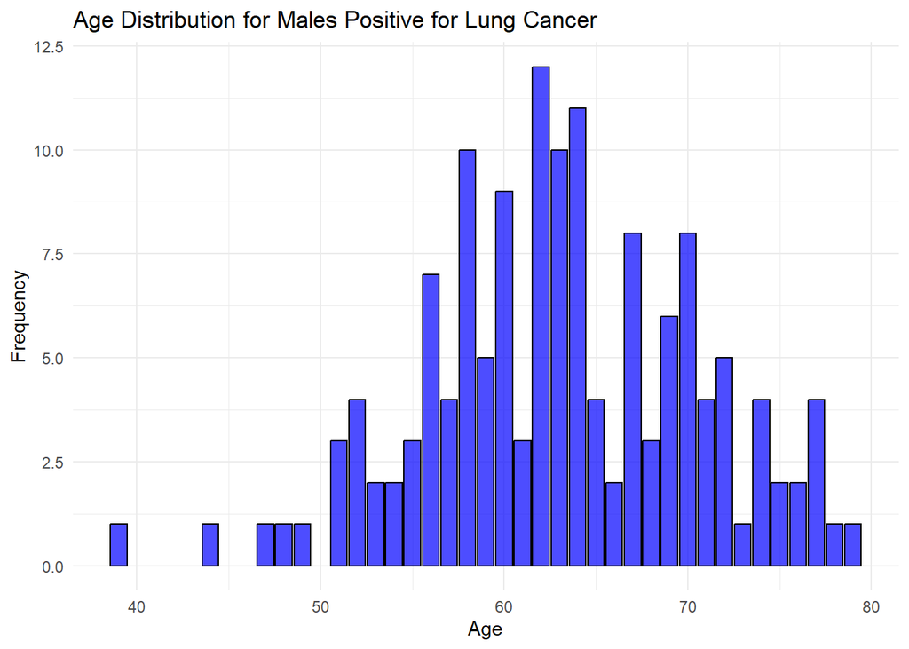

```r
# Ensure that AGE is numeric
lc_data$AGE <- as.numeric(lc_data$AGE)

# Filter the dataset for males who are positive for lung cancer
males_lung_cancer <- subset(lc_data, GENDER == "M" & LUNG_CANCER == "YES")

# Plot the age distribution for these individuals
ggplot(males_lung_cancer, aes(x = AGE)) +
  geom_histogram(binwidth = 1, fill = "blue", color = "black", alpha = 0.7, stat = "count") +
  labs(title = "Age Distribution for Males Positive for Lung Cancer",
       x = "Age",
       y = "Frequency") +
  theme_minimal()
```

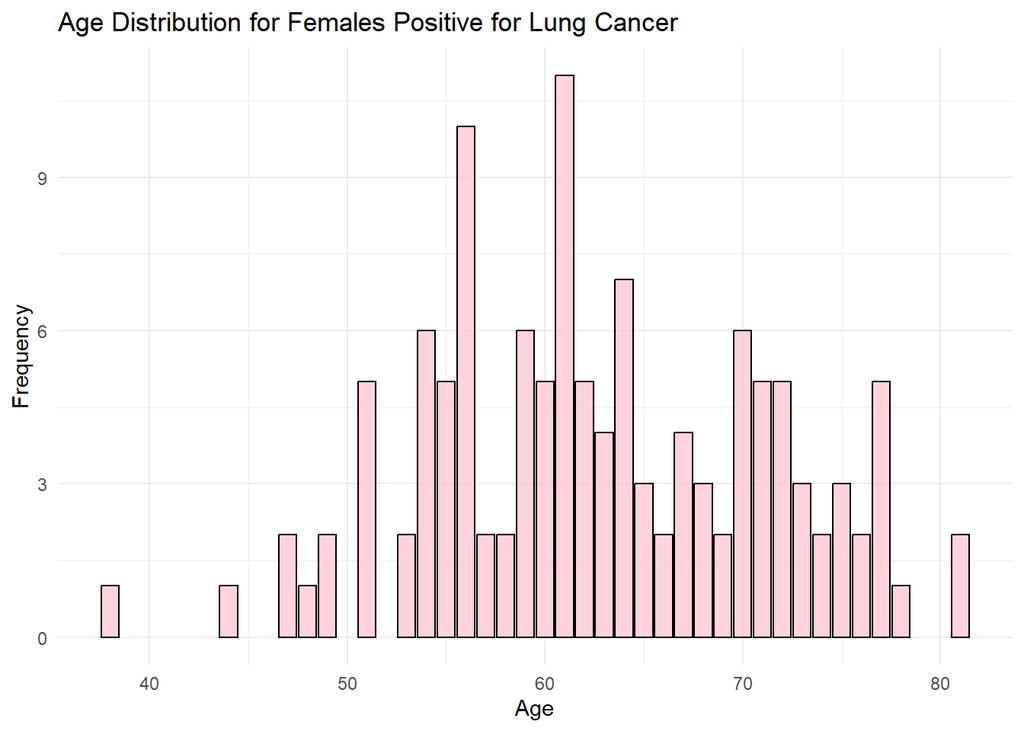

```r
# Filter the dataset for females who are positive for lung cancer
females_lung_cancer <- subset(lc_data, GENDER == "F" & LUNG_CANCER == "YES")

# Plot the age distribution for these individuals
ggplot(females_lung_cancer, aes(x = AGE)) +
  geom_histogram(binwidth = 1, fill = "pink", color = "black", alpha = 0.7, stat = "count") +
  labs(title = "Age Distribution for Females Positive for Lung Cancer",
       x = "Age",
       y = "Frequency") +
  theme_minimal()
```

Explore bivariate relationships with lung cancer.

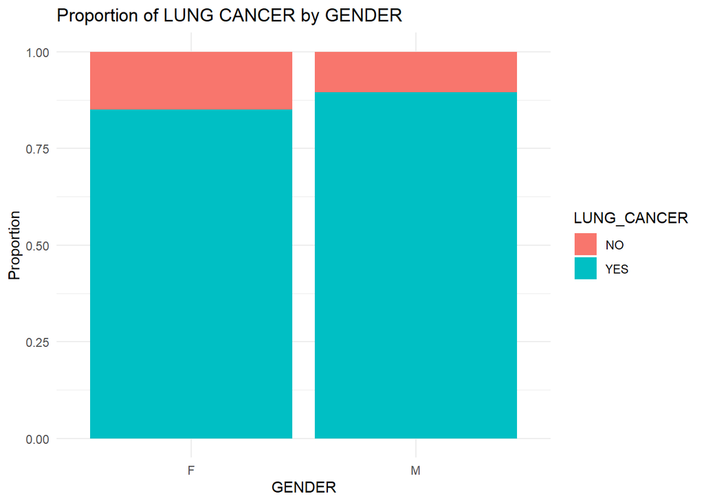

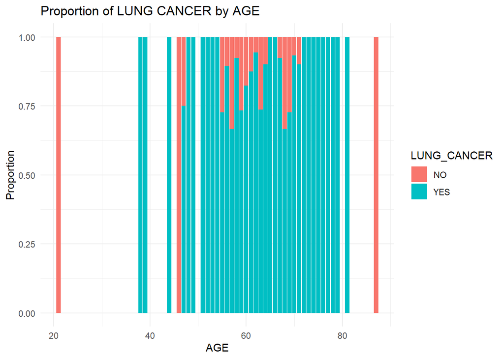

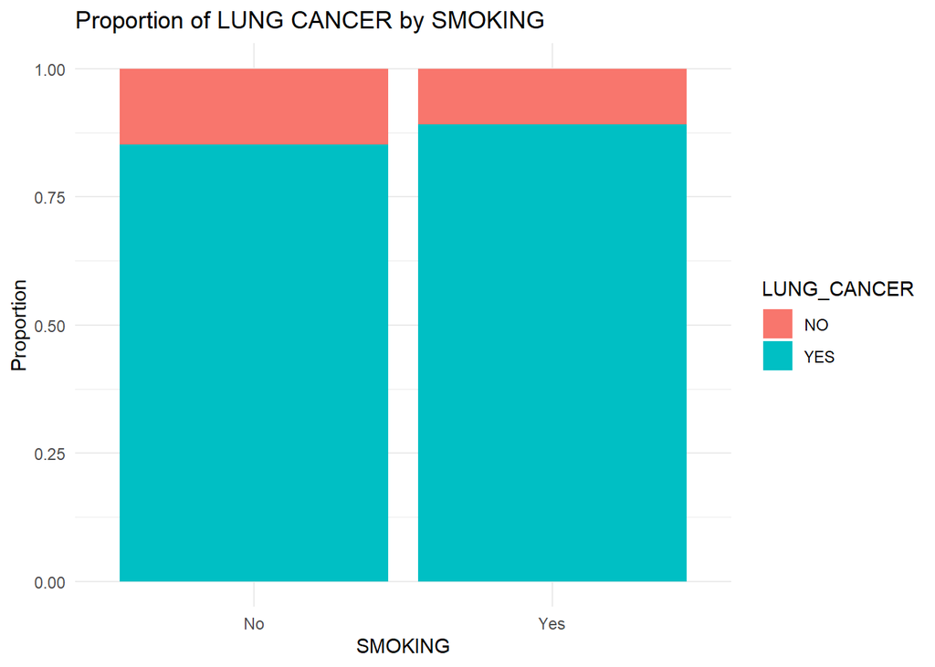

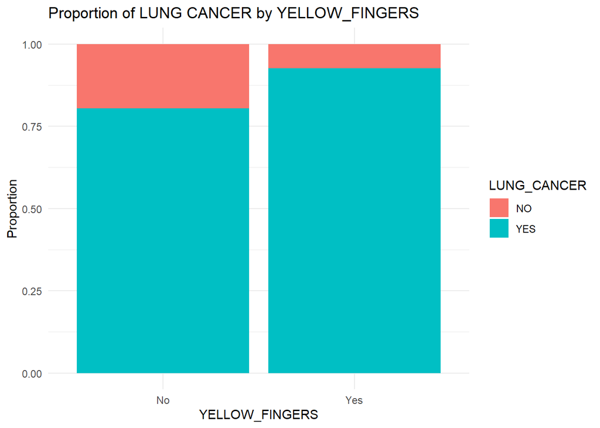

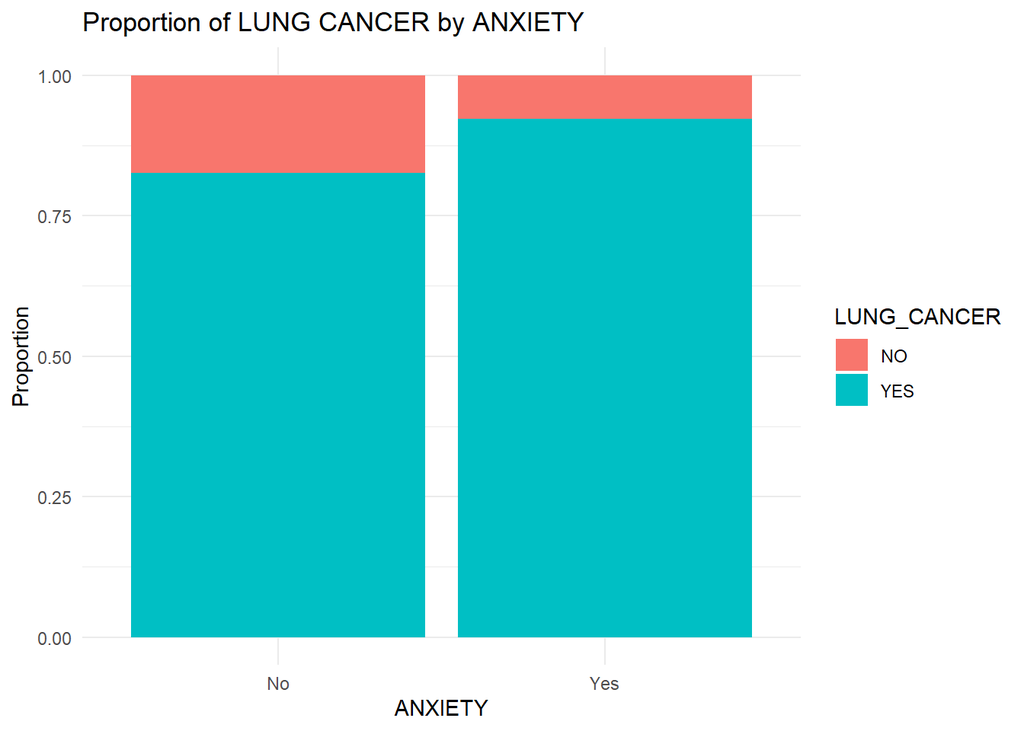

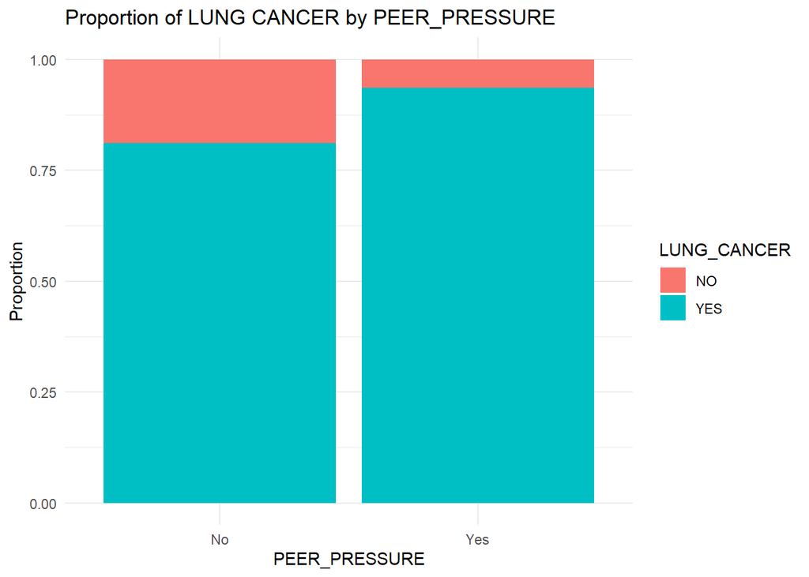

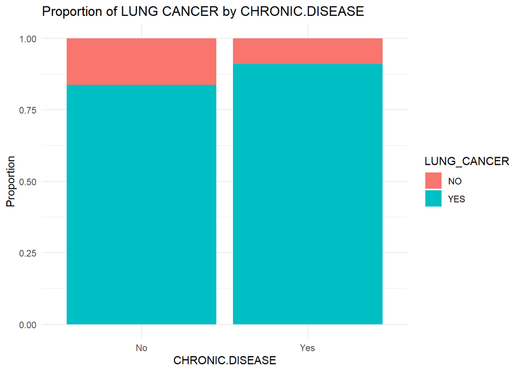

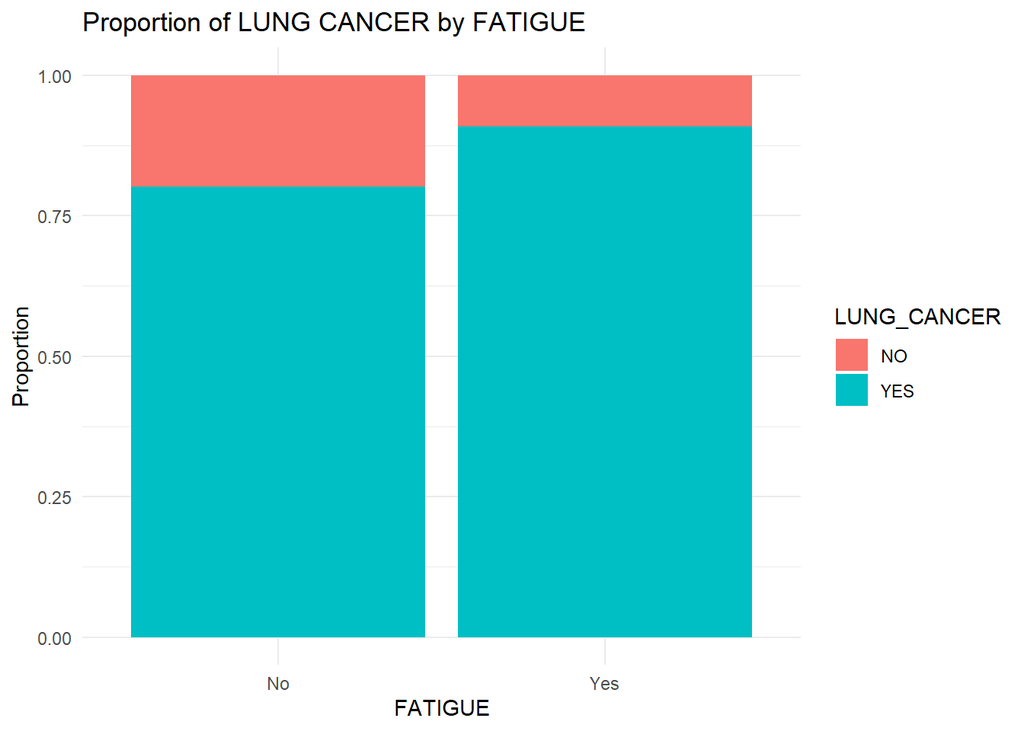

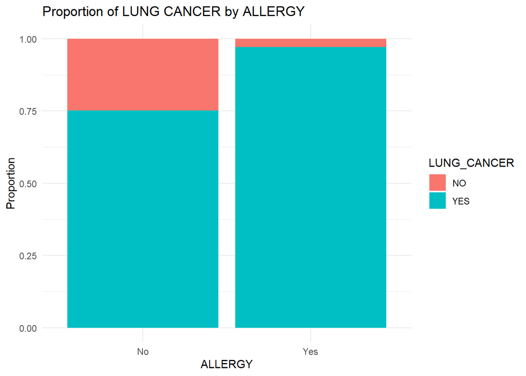

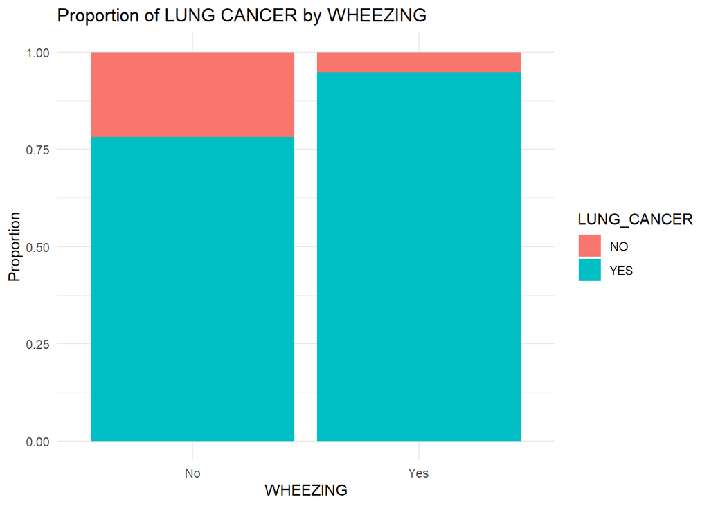

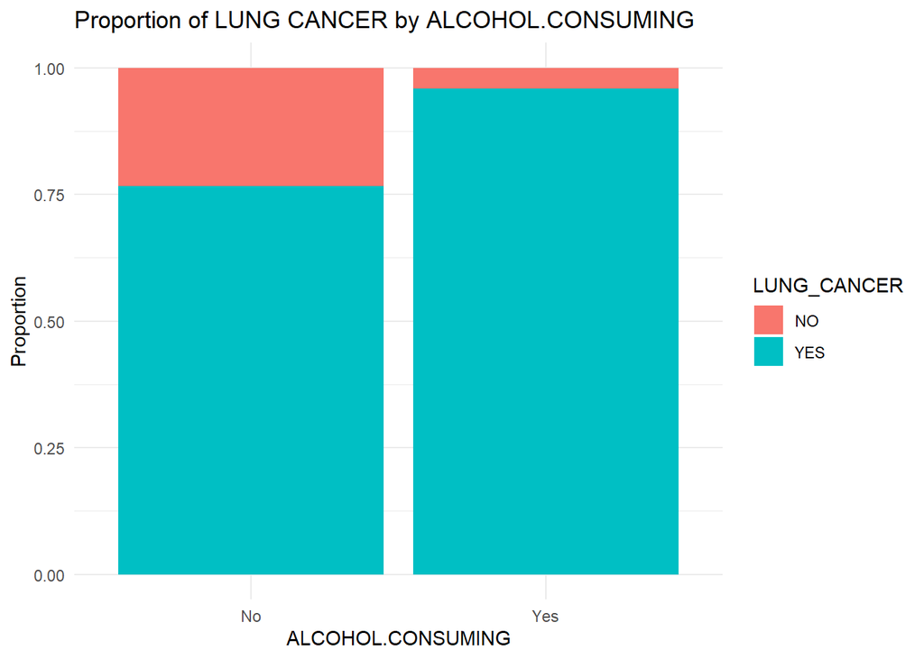

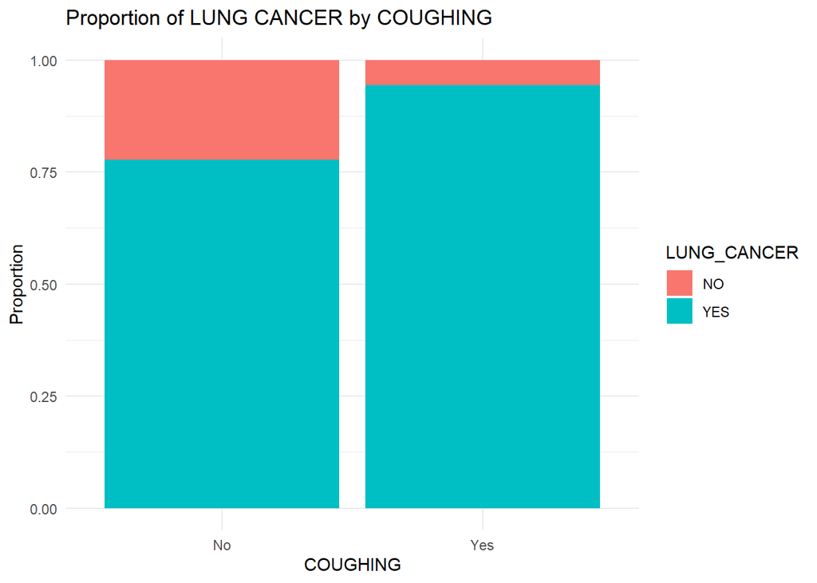

[3 more figures not shown]

```r
# Create a loop to generate proportion plots for all variables vs lung cancer
for (var in colnames(lc_data)) {
  # Skip the LUNG_CANCER column as it's used for grouping
  if (var != "LUNG_CANCER") {
    p <- ggplot(lc_data, aes_string(x = var, fill = "LUNG_CANCER")) +
      geom_bar(position = "fill") +
      labs(title = paste("Proportion of LUNG CANCER by", var), x = var, y = "Proportion") +
      theme_minimal()

    # Print the plot
    print(p)
  }
}
```

```r
# Train Logistic Regression Model

logit_model <- train(
  LUNG_CANCER ~ ., data = trainData,
  method = "glm",  # 'glm' method for Generalized Linear Model (logistic regression)
  family = binomial(),  # Ensure logistic regression
  trControl = trainControl(method = "cv", number = 5)
)
# Print Logistic Regression Model Summary
print(logit_model)
```

```
## Generalized Linear Model
##
## 217 samples
##  15 predictor
##   2 classes: 'NO', 'YES'
##
## No pre-processing
## Resampling: Cross-Validated (5 fold)
## Summary of sample sizes: 174, 173, 174, 174, 173
## Resampling results:
##
##   Accuracy   Kappa
##   0.9031712  0.5341278
```

```r
# Make predictions
predictions_logistic <- predict(logit_model, testData)

# Confusion Matrix
confusionMatrix(predictions_logistic, testData$LUNG_CANCER)
```

```
## Confusion Matrix and Statistics
##
##           Reference
## Prediction NO YES
##        NO   4   2
##        YES  7  79
##
##                Accuracy : 0.9022
##                  95% CI : (0.8224, 0.9543)
##     No Information Rate : 0.8804
##     P-Value [Acc > NIR] : 0.3266
##
##                   Kappa : 0.4218
##
##  Mcnemar's Test P-Value : 0.1824
##
##             Sensitivity : 0.36364
##             Specificity : 0.97531
##          Pos Pred Value : 0.66667
##          Neg Pred Value : 0.91860
##              Prevalence : 0.11957
##          Detection Rate : 0.04348
##    Detection Prevalence : 0.06522
##       Balanced Accuracy : 0.66947
##
##        'Positive' Class : NO
##
```

ROC Curve:

True Positive Rate (TPR) or Sensitivity:

# TPR

Measures the proportion of actual positives correctly identified.

False Positive Rate (FPR):

# FPR

False Positives /False Positives + True Negatives

Measures the proportion of actual negatives incorrectly identified as positive.

Thresholds:

The model assigns probabilities to each instance, and the ROC curve is generated by varying the decision threshold for classifying an observation as “positive” or “negative.”

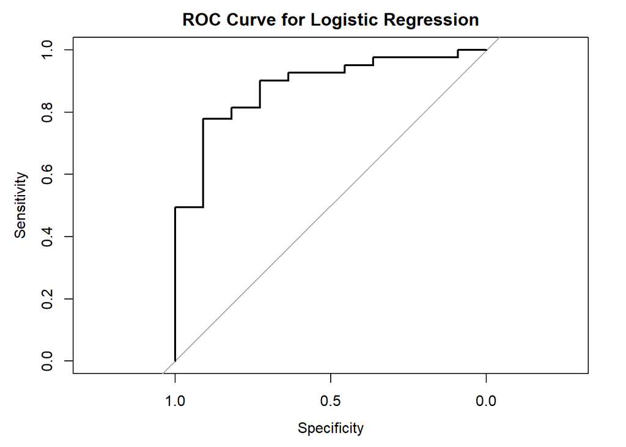

```r
# Get predicted probabilities
probabilities <- predict(logit_model, testData, type = "prob")[,2]

# Compute ROC curve
roc_curve <- roc(testData$LUNG_CANCER, probabilities)
# Plot the ROC curve
plot(roc_curve, main = "ROC Curve for Logistic Regression")
```

```r
auc <- auc(roc_curve)
cat("AUC:", auc, "\n")
```

```
## AUC: 0.8832772
```

The y-axis represents TPR or how many positive samples were correctly classified.

Top left corner is the ideal performance, where TPR=1 and FPR=0

A model whose ROC curve is close to the diagonal line has little discriminatory power.

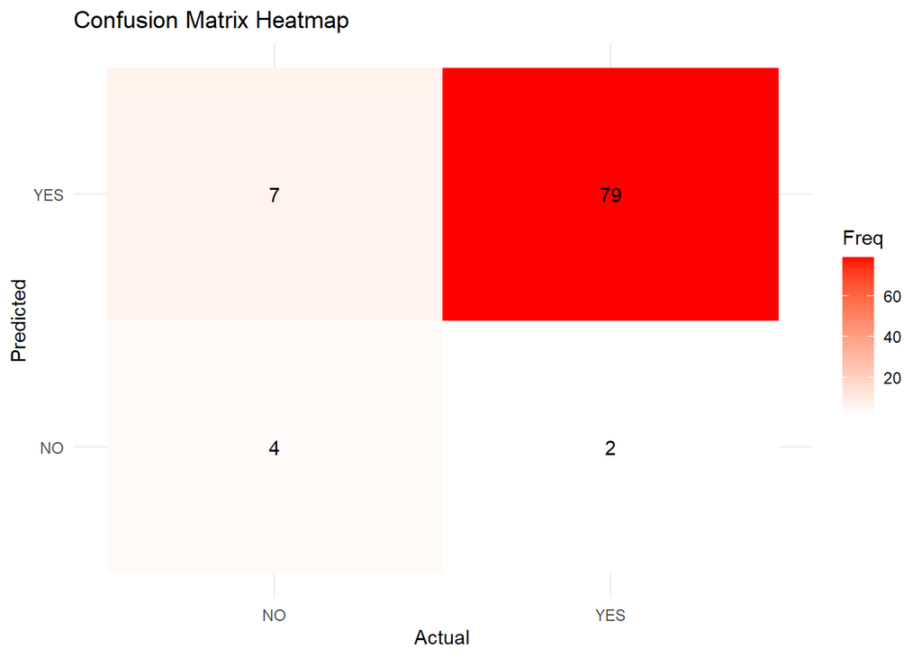

```r
# Create confusion matrix
conf_matrix <- confusionMatrix(predictions_logistic, testData$LUNG_CANCER)

# Convert to table
conf_mat_table <- as.table(conf_matrix$table)

# Plot heatmap
ggplot(as.data.frame(conf_mat_table), aes(Reference, Prediction, fill = Freq)) +
  geom_tile() +
  scale_fill_gradient(low = "white", high = "red") +
  geom_text(aes(label = Freq), color = "black") +
  labs(title = "Confusion Matrix Heatmap", x = "Actual", y = "Predicted") +
  theme_minimal()
```

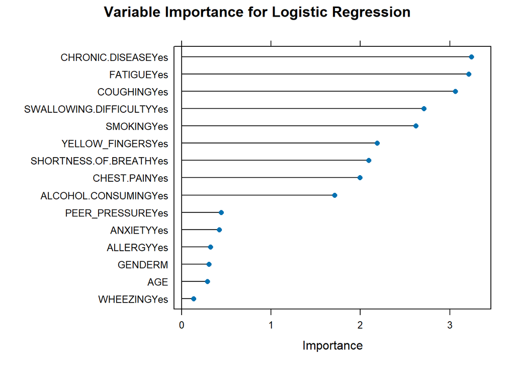

```r
var_imp <- varImp(logit_model, scale = FALSE)

# Plot variable importance
plot(var_imp, main = "Variable Importance for Logistic Regression")
```